# ARIMA MODEL

Elbrus Gasimov, Alberto Delgado Lopez

6/2/2021

## Literature review

During the analysis and after the analysis to check every step and final result below sources have been used

- https://datascienceplus.com/time-series-analysis-using-arima-model-in-r/
- https://otexts.com/fpp2/arima-r.html
- https://www.analyticsvidhya.com/blog/2015/12/complete-tutorial-time-series-modeling/
- https://blogs.oracle.com/ai-and-datascience/post/introduction-to-forecasting-with-arima-in-r
- https://rpubs.com/riazakhan94/arima_with_example

## Introduction

The idea of this work is to study and analyse, using time series metrics, the most recent data on Covid-19 deaths in the state of California. The main goal here is to predict death cases for short term and long term. Will build ARIMA model and then compare all possible valid models and choose the best one to handle our forecast!

### Data info

Our Dataset is about Covid Cases in US, California. It is a daily data and it comes from the ‘California health and human services open data portal’:

https://data.chhs.ca.gov/dataset/covid-19-time-series-metrics-by-county-and-state

As we focus on ARIMA model to predict death cases for this file we will focuc on the first dataset, where will observe deaths for a year and then will predict for long ans short time period.

```r
#Libraries
library(lmtest)
library(fBasics)
library(urca)
library(xts)
library(forecast)
library(quantmod)
# load needed packages
library(xts)
library(fBasics)
library(urca)
source("function_testdf2.R")
source("function_import_data_into_xts.R")
# libraries
requiredPackages = c("lmtest","fBasics","urca","xts","forecast", "quantmod", "reshape2")

for(i in requiredPackages){if(!require(i,character.only = TRUE)) install.packages(i)}
for(i in requiredPackages){if(!require(i,character.only = TRUE)) library(i,character.only = TRUE)}
```

### Lodading the Dataset.

Importing the dataset and exploring it a bitLets load the datasets, analyse the data, do a little bit of cleaning and reorganize variables.

```r
covid <- read.csv("main_case.csv", # name of the file
                header = T,     # if first row doesn't contain variable names: header=F'
                sep = ",",    # sign used as columns separator
                dec = ".")    # sign used as decimal place separator
head(covid)
```

```
##         date         area area_type population cases deaths total_tests
## 1 2021-04-21      Alameda    County    1685886     0      0          NA
## 2 2021-04-21       Alpine    County       1117     0      0          NA
## 3 2021-04-21        Butte    County     217769     0      0          NA
## 4 2021-04-21 Contra Costa    County    1160099     0      0          NA
## 5 2021-04-21         Kern    County     927251     0      0          NA
## 6 2021-04-21 Out of state    County         NA    NA     NA          NA
##   positive_tests reported_cases reported_deaths reported_tests
## 1             NA            110               1          20804
## 2             NA              1               0             10
## 3             NA             24               0            730
## 4             NA             92               0           9687
## 5             NA             34               2           2901
## 6             NA             NA              NA           4163
```

```r
tail(covid)
```

```
##             date     area area_type population cases deaths total_tests
## 27201 2020-02-01   Solano    County     444255    NA     NA           1
## 27202 2020-02-01 Imperial    County     191649    NA     NA           0
## 27203 2020-02-01   Nevada    County      98710    NA     NA           0
## 27204 2020-02-01  Unknown    County         NA    NA     NA           0
## 27205 2020-02-01   Merced    County     287420    NA     NA           0
## 27206 2020-02-01     Yolo    County     223612    NA     NA           0
##       positive_tests reported_cases reported_deaths reported_tests
## 27201              0              0               0             NA
## 27202              0              0               0             NA
## 27203              0              0               0             NA
## 27204              0              0               0             NA
## 27205              0              0               0             NA
## 27206              0              0               0             NA
```

```r
summary(covid)
```

```
##      date               area            area_type           population
##  Length:27206       Length:27206       Length:27206       Min.   :    1117
##  Class :character   Class :character   Class :character   1st Qu.:   44289
##  Mode  :character   Mode  :character   Mode  :character   Median :  193098
##                                                           Mean   : 1360311
##                                                           3rd Qu.:  782545
##                                                           Max.   :40129160
##                                                           NA's   :892
##      cases             deaths         total_tests     positive_tests
##  Min.   :    0.0   Min.   :  0.000   Min.   :     0   Min.   :    0.0
##  1st Qu.:    2.0   1st Qu.:  0.000   1st Qu.:    31   1st Qu.:    0.0
##  Median :   16.0   Median :  0.000   Median :   288   Median :   12.0
##  Mean   :  289.7   Mean   :  4.775   Mean   :  4305   Mean   :  319.9
##  3rd Qu.:   84.0   3rd Qu.:  1.000   3rd Qu.:  1597   3rd Qu.:   82.0
##  Max.   :60256.0   Max.   :683.000   Max.   :478289   Max.   :73432.0
##  NA's   :2186      NA's   :2186      NA's   :61       NA's   :61
##  reported_cases    reported_deaths    reported_tests
##  Min.   :-5064.0   Min.   :-175.000   Min.   :-76951
##  1st Qu.:    0.0   1st Qu.:   0.000   1st Qu.:   108
##  Median :   10.0   Median :   0.000   Median :   502
##  Mean   :  270.9   Mean   :   4.484   Mean   :  5316
##  3rd Qu.:   73.0   3rd Qu.:   1.000   3rd Qu.:  1992
##  Max.   :61016.0   Max.   :1178.000   Max.   :473076
##  NA's   :446       NA's   :446        NA's   :5734
```

```r
str(covid)
```

```
## 'data.frame':    27206 obs. of  11 variables:
##  $ date           : chr  "2021-04-21" "2021-04-21" "2021-04-21" "2021-04-21" ...
##  $ area           : chr  "Alameda" "Alpine" "Butte" "Contra Costa" ...
##  $ area_type      : chr  "County" "County" "County" "County" ...
##  $ population     : num  1685886 1117 217769 1160099 927251 ...
##  $ cases          : num  0 0 0 0 0 NA 0 0 0 0 ...
##  $ deaths         : num  0 0 0 0 0 NA 0 0 0 0 ...
##  $ total_tests    : num  NA NA NA NA NA NA NA NA NA NA ...
##  $ positive_tests : num  NA NA NA NA NA NA NA NA NA NA ...
##  $ reported_cases : num  110 1 24 92 34 NA 50 20 0 105 ...
##  $ reported_deaths: num  1 0 0 0 2 NA 0 0 0 0 ...
##  $ reported_tests : num  20804 10 730 9687 2901 ...
```

```r
covid$date <- as.Date(covid$date, "%Y-%m-%d")

covid<-covid[,c(1,6)]
covid<-na.omit(covid)
covid<-aggregate(covid[,-1], by = list(covid$date), FUN = sum)
names(covid) <- c("date","deaths")

head(covid)
```

```
##         date deaths
## 1 2020-03-01      0
## 2 2020-03-02      0
## 3 2020-03-03      2
## 4 2020-03-04      2
## 5 2020-03-05      0
## 6 2020-03-06      2
```

```r
tail(covid)
```

```
##           date deaths
## 412 2021-04-16      6
## 413 2021-04-17     18
## 414 2021-04-18     12
## 415 2021-04-19      6
## 416 2021-04-20      2
## 417 2021-04-21      0
```

```r
summary(covid)
```

```
##       date                deaths
##  Min.   :2020-03-01   Min.   :   0.0
##  1st Qu.:2020-06-13   1st Qu.: 110.0
##  Median :2020-09-25   Median : 158.0
##  Mean   :2020-09-25   Mean   : 286.5
##  3rd Qu.:2021-01-07   3rd Qu.: 278.0
##  Max.   :2021-04-21   Max.   :1366.0
```

```r
str(covid)
```

```
## 'data.frame':    417 obs. of  2 variables:
##  $ date  : Date, format: "2020-03-01" "2020-03-02" ...
##  $ deaths: num  0 0 2 2 0 2 0 0 6 0 ...
```

## Times Series object

Let’s create the xts objects

```r
head(covid)
```

```
##         date deaths
## 1 2020-03-01      0
## 2 2020-03-02      0
## 3 2020-03-03      2
## 4 2020-03-04      2
## 5 2020-03-05      0
## 6 2020-03-06      2
```

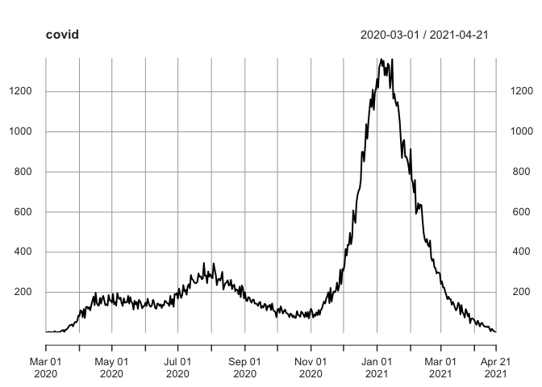

```r
covid <- xts(covid[,-1], order.by=covid$date)
names(covid) <- c("deaths")
plot(covid)
```

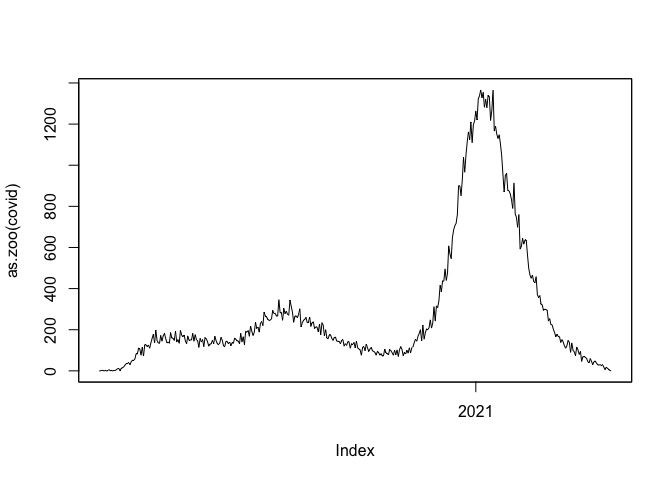

```r
plot(as.zoo(covid))
```

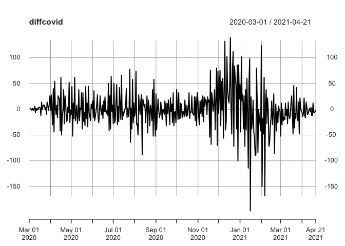

```r
diffcovid <- diff.xts(covid)
plot(diffcovid)
```

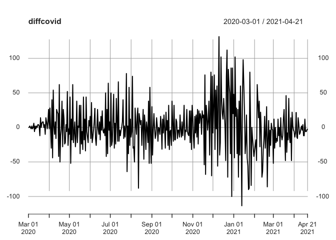

```r
diffcovid$deaths <- tsclean(diffcovid$deaths)
plot(diffcovid)
```

```r
df.test <- ur.df(diffcovid$deaths,
                 type = c('none'),
                 lags = 0)

summary((df.test))
```

```
##
## ###############################################
## # Augmented Dickey-Fuller Test Unit Root Test #
## ###############################################
##
## Test regression none
##
##
## Call:
## lm(formula = z.diff ~ z.lag.1 - 1)
##
## Residuals:
##      Min       1Q   Median       3Q      Max
## -116.148  -15.889   -1.148   16.153  141.667
##
## Coefficients:
##         Estimate Std. Error t value Pr(>|t|)
## z.lag.1 -1.26852    0.04729  -26.83   <2e-16 ***
## ---
## Signif. codes:  0 '***' 0.001 '**' 0.01 '*' 0.05 '.' 0.1 ' ' 1
##
## Residual standard error: 32.6 on 415 degrees of freedom
## Multiple R-squared:  0.6343, Adjusted R-squared:  0.6334
## F-statistic: 719.7 on 1 and 415 DF,  p-value: < 2.2e-16
##
##
## Value of test-statistic is: -26.8268
##
## Critical values for test statistics:
##       1pct  5pct 10pct
## tau1 -2.58 -1.95 -1.62
```

```r
resids_ <- df.test@testreg$residuals
bgtest(resids_~1, order = 1)
```

```
##
##  Breusch-Godfrey test for serial correlation of order up to 1
##
## data:  resids_ ~ 1
## LM test = 9.9574e-05, df = 1, p-value = 0.992
```

```r
bgtest(resids_~1, order = 2)
```

```
##
##  Breusch-Godfrey test for serial correlation of order up to 2
##
## data:  resids_ ~ 1
## LM test = 0.15392, df = 2, p-value = 0.9259
```

```r
bgtest(resids_~1, order = 3)
```

```
##
##  Breusch-Godfrey test for serial correlation of order up to 3
##
## data:  resids_ ~ 1
## LM test = 4.6298, df = 3, p-value = 0.201
```

```r
bgtest(resids_~1, order = 4)
```

```
##
##  Breusch-Godfrey test for serial correlation of order up to 4
##
## data:  resids_ ~ 1
## LM test = 19.661, df = 4, p-value = 0.0005826
```

```r
bgtest(resids_~1, order = 5)
```

```
##
##  Breusch-Godfrey test for serial correlation of order up to 5
##
## data:  resids_ ~ 1
## LM test = 21.498, df = 5, p-value = 0.000652
```

## Residuals check

To be sure that conlusions may be drawn we need to check whether there is no autocorrelation in residuals adf.test performance

```r
adf.test<- ur.df(diffcovid$deaths,
                 type = c('none'),
                 lags = 5)
summary(adf.test)
```

```
##
## ###############################################
## # Augmented Dickey-Fuller Test Unit Root Test #
## ###############################################
##
## Test regression none
##
##
## Call:
## lm(formula = z.diff ~ z.lag.1 - 1 + z.diff.lag)
##
## Residuals:
##      Min       1Q   Median       3Q      Max
## -114.059  -15.750   -0.416   16.964  133.842
##
## Coefficients:
##             Estimate Std. Error t value Pr(>|t|)
## z.lag.1     -0.76720    0.13004  -5.900 7.70e-09 ***
## z.diff.lag1 -0.53923    0.12287  -4.389 1.46e-05 ***
## z.diff.lag2 -0.55903    0.11528  -4.849 1.77e-06 ***
## z.diff.lag3 -0.46365    0.10158  -4.565 6.65e-06 ***
## z.diff.lag4 -0.24389    0.08065  -3.024  0.00265 **
## z.diff.lag5 -0.12061    0.04934  -2.444  0.01494 *
## ---
## Signif. codes:  0 '***' 0.001 '**' 0.01 '*' 0.05 '.' 0.1 ' ' 1
##
## Residual standard error: 31.94 on 405 degrees of freedom
## Multiple R-squared:  0.6572, Adjusted R-squared:  0.6522
## F-statistic: 129.4 on 6 and 405 DF,  p-value: < 2.2e-16
##
##
## Value of test-statistic is: -5.8996
##
## Critical values for test statistics:
##       1pct  5pct 10pct
## tau1 -2.58 -1.95 -1.62
```

```r
resids_ <- adf.test@testreg$residuals
bgtest(resids_~1, order = 1)
```

```
##
##  Breusch-Godfrey test for serial correlation of order up to 1
##
## data:  resids_ ~ 1
## LM test = 0.018981, df = 1, p-value = 0.8904
```

```r
bgtest(resids_~1, order = 2)
```

```
##
##  Breusch-Godfrey test for serial correlation of order up to 2
##
## data:  resids_ ~ 1
## LM test = 0.025594, df = 2, p-value = 0.9873
```

```r
bgtest(resids_~1, order = 3)
```

```
##
##  Breusch-Godfrey test for serial correlation of order up to 3
##
## data:  resids_ ~ 1
## LM test = 0.044776, df = 3, p-value = 0.9975
```

```r
bgtest(resids_~1, order = 4)
```

```
##
##  Breusch-Godfrey test for serial correlation of order up to 4
##
## data:  resids_ ~ 1
## LM test = 0.37387, df = 4, p-value = 0.9846
```

```r
bgtest(resids_~1, order = 5)
```

```
##
##  Breusch-Godfrey test for serial correlation of order up to 5
##
## data:  resids_ ~ 1
## LM test = 1.3735, df = 5, p-value = 0.9272
```

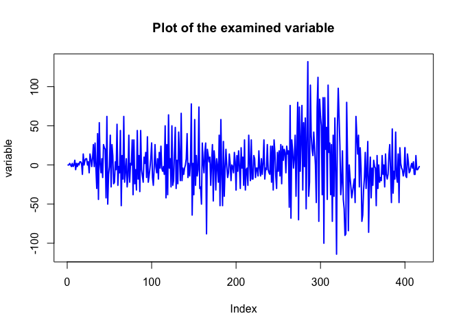

```
##   augmentations        adf p_adf p_bg.p.value.1 p_bg.p.value.2 p_bg.p.value.3
## 1             0 -26.826800  0.01      0.9920383      0.9259252      0.2009989
## 2             1 -16.102995  0.01      0.9814033      0.9622735      0.2022230
## 3             2 -11.886659  0.01      0.8067983      0.9618112      0.8236333
## 4             3  -8.383620  0.01      0.7193320      0.7895599      0.9234523
## 5             4  -7.075606  0.01      0.8237050      0.9067947      0.9781121
## 6             5  -5.899622  0.01      0.8904219      0.9872846      0.9975137
##   p_bg.p.value.4 p_bg.p.value.5
## 1   0.0005825615   0.0006519581
## 2   0.0006271474   0.0006833218
## 3   0.0009578135   0.0012221458
## 4   0.9709385412   0.6115460368
## 5   0.9856291740   0.9963188900
## 6   0.9845594081   0.9271953596
```

```r
testdf2(variable = diffcovid$deaths,
        test.type = 'nc',
        max.augmentations = 5,
        max.order = 5)
```

As we reject the H0 we comfirm that your variable is Stationary!

## Alternative tests

To check the residuals there here are some test we can conduct!

```r
pp.test.d <-ur.pp(diffcovid$deaths,
                  type =  c("Z-tau"),
                  model = c("constant"))

summary(pp.test.d)
```

```
##
## ##################################
## # Phillips-Perron Unit Root Test #
## ##################################
##
## Test regression with intercept
##
##
## Call:
## lm(formula = y ~ y.l1)
##
## Residuals:
##      Min       1Q   Median       3Q      Max
## -117.106  -16.838   -2.106   15.184  140.736
##
## Coefficients:
##             Estimate Std. Error t value Pr(>|t|)
## (Intercept)  0.95316    1.59975   0.596    0.552
## y.l1        -0.26915    0.04733  -5.686 2.46e-08 ***
## ---
## Signif. codes:  0 '***' 0.001 '**' 0.01 '*' 0.05 '.' 0.1 ' ' 1
##
## Residual standard error: 32.62 on 414 degrees of freedom
## Multiple R-squared:  0.07244,    Adjusted R-squared:  0.0702
## F-statistic: 32.33 on 1 and 414 DF,  p-value: 2.458e-08
##
##
## Value of test-statistic, type: Z-tau  is: -26.1315
##
##          aux. Z statistics
## Z-tau-mu            0.5806
##
## Critical values for Z statistics:
##                     1pct     5pct     10pct
## critical values -3.44809 -2.86873 -2.570583
```

pp test here comfirms that our variable is stationary. Generaly, the result of df and pp tests should be the same just like ours to be in the safe side howver if the results are different then we contine testing with the 3rd test KPSS test has a different H0 which is ts is stationary

```r
kpps.test <- ur.kpss(diffcovid$deaths,
                     type = c('mu'))
summary(kpps.test)
```

```
##
## #######################
## # KPSS Unit Root Test #
## #######################
##
## Test is of type: mu with 5 lags.
##
## Value of test-statistic is: 0.3022
##
## Critical value for a significance level of:
##                 10pct  5pct 2.5pct  1pct
## critical values 0.347 0.463  0.574 0.739
```

As a result we get that we fail to reject H0 which is our variable is stationary our 5 percent rejecttion intervals starts from 0.463 till plus infinite our t statistics value is 0.3022 means it is out of the rejection zone!!

The Box-Jenkins procedure Initial identification of parameters p and q:we need to see if the residuals are autocorrelated or not! if not then we have a good model we can use the model to calculate the forecast, however if residuals are autocorrelated then we need to increase p and q values and estimate the model again

## ACF and PACF stationary test

### ACF

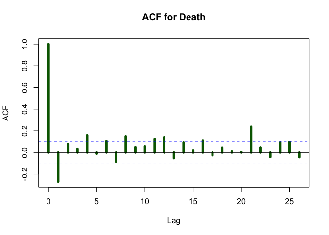

```r
acf(diffcovid$deaths,
    lwd = 5, # line width
    col = "dark green", # color
    main = "ACF for Death")
```

### PACF

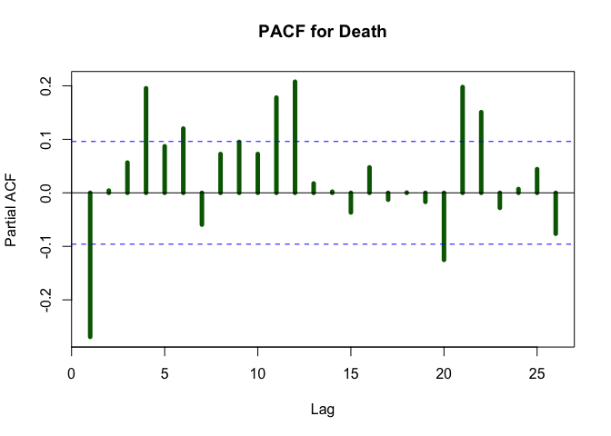

```r
pacf(diffcovid$deaths,
     lwd = 5, # line width
     col = "dark green", # color
     main = "PACF for Death")
```

As we have daily data,then my approuch we be to see if we have any pattern repeating itsel as i can see somehow there is a weekly pattern, which makes feel choosing p = 5 and q = 5 We have done all steps and it is time to check our model for this we will start with creating the model and we will use Arima() ## as it is better than arima(), because it allows us to include constant term to the varibale

```r
arima1 <- Arima(covid$deaths,
                order = c(5,1,5),
                include.constant = TRUE)

summary(arima1)
```

```
## Series: covid$deaths
## ARIMA(5,1,5) with drift
##
## Coefficients:
##          ar1     ar2     ar3     ar4      ar5      ma1      ma2     ma3
##       0.3469  0.3243  0.0863  0.4347  -0.2579  -0.9338  -0.1022  0.1958
## s.e.  0.3361  0.7060  0.2654  0.6710   0.0771   0.3301   0.6379  0.6788
##           ma4     ma5    drift
##       -0.2944  0.3391  -0.2413
## s.e.   0.5309  0.5271   4.3678
##
## sigma^2 estimated as 945.8:  log likelihood=-2011.04
## AIC=4046.08   AICc=4046.86   BIC=4094.45
##
## Training set error measures:
##                        ME     RMSE    MAE MPE MAPE      MASE       ACF1
## Training set -0.005313465 30.30836 20.864 NaN  Inf 0.7974478 -0.0011144
```

This output is not exaclty what we want so lets check coeftest() function, from the lmtest package to test the significance of model parameters.

```r
coeftest(arima1)
```

```
##
## z test of coefficients:
##
##        Estimate Std. Error z value  Pr(>|z|)
## ar1    0.346911   0.336119  1.0321 0.3020222
## ar2    0.324277   0.705963  0.4593 0.6459900
## ar3    0.086298   0.265372  0.3252 0.7450328
## ar4    0.434680   0.670974  0.6478 0.5170918
## ar5   -0.257918   0.077127 -3.3441 0.0008256 ***
## ma1   -0.933767   0.330137 -2.8284 0.0046778 **
## ma2   -0.102160   0.637923 -0.1601 0.8727674
## ma3    0.195799   0.678845  0.2884 0.7730181
## ma4   -0.294388   0.530926 -0.5545 0.5792507
## ma5    0.339102   0.527121  0.6433 0.5200232
## drift -0.241299   4.367759 -0.0552 0.9559429
## ---
## Signif. codes:  0 '***' 0.001 '**' 0.01 '*' 0.05 '.' 0.1 ' ' 1
```

From the results we can see that 5th lag from AR and 1st lag from MA is statisticly significiant now lets check if the model is valid!

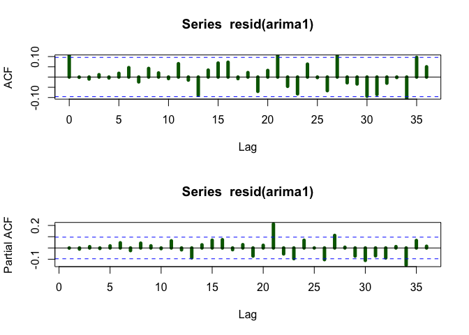

```r
par(mfrow = c(2,1))
acf(resid(arima1),
    lag.max = 36,
    ylim = c(-0.1,0.1),
    lwd = 5, col = "dark green",
    na.action = na.pass)
pacf(resid(arima1),
     lag.max = 36,
     lwd = 5, col = "dark green",
     na.action = na.pass)
```

```r
par(mfrow = c(1,1))
```

## Ljung-Box test

From the plot it is shown that we have autocorrelation of residuals however there is a better tool to check autocorrelation which is Ljung-Box test for max 10 lags

```r
Box.test(resid(arima1),
         type = 'Ljung-Box',
         lag = 10)
```

```
##
##  Box-Ljung test
##
## data:  resid(arima1)
## X-squared = 2.3224, df = 10, p-value = 0.9932
```

H0 for Ljung-Box is that, Residuals are fine, means there is not auto correlation! we used lag = 10 means, there is no autocorrelation - order = 1, order = 2…..order = 10 as our p value is 0.9932 we fail to reject H0 which means our model is valid!however to obtan more percise model i can restrict my model further by droping statisticly insiginificant models and then we can compare which one is better model

```r
arima1_1 <- Arima(covid$deaths,
                    order = c(5,1,5),
                    fixed = c(0,0,0,0,NA,  # vector of the same
                              NA,0,0,0,0,NA), # length as the total number of parameters
                    include.constant = TRUE  # last is for the intercept (if included)
)

summary(arima1_1)
```

```
## Series: covid$deaths
## ARIMA(5,1,5) with drift
##
## Coefficients:
##       ar1  ar2  ar3  ar4     ar5      ma1  ma2  ma3  ma4  ma5   drift
##         0    0    0    0  0.1062  -0.3245    0    0    0    0  0.0001
## s.e.    0    0    0    0  0.0597   0.0457    0    0    0    0  1.3240
##
## sigma^2 estimated as 1287:  log likelihood=-2078.12
## AIC=4164.24   AICc=4164.34   BIC=4180.36
##
## Training set error measures:
##                        ME     RMSE     MAE  MPE MAPE      MASE        ACF1
## Training set 0.0003574552 35.69964 24.3088 -Inf  Inf 0.9291127 -0.05862584
```

```r
coeftest(arima1_1)
```

```
##
## z test of coefficients:
##
##          Estimate  Std. Error z value  Pr(>|z|)
## ar5    1.0616e-01  5.9677e-02  1.7789   0.07525 .
## ma1   -3.2449e-01  4.5652e-02 -7.1079 1.178e-12 ***
## drift  9.9391e-05  1.3240e+00  0.0001   0.99994
## ---
## Signif. codes:  0 '***' 0.001 '**' 0.01 '*' 0.05 '.' 0.1 ' ' 1
```

```r
Box.test(resid(arima1_1),
         type = 'Ljung-Box',
         lag = 10)
```

```
##
##  Box-Ljung test
##
## data:  resid(arima1_1)
## X-squared = 146.86, df = 10, p-value < 2.2e-16
```

## Model Copmarision

### AIC

```r
AIC(arima1, arima1_1)
```

```
##          df      AIC
## arima1   12 4046.084
## arima1_1  4 4164.240
```

### BIC

```r
BIC(arima1, arima1_1)
```

```
##          df      BIC
## arima1   12 4094.452
## arima1_1  4 4180.362
```

Furthermore there is also a way to create the best model for this we can use auto.arima() function lets try and then we can compare all the models

```r
auto_arima.AIC <- auto.arima(covid$deaths,
                             d = 1,             # parameter d of ARIMA model
                             max.p = 10,        # Maximum value of p
                             max.q = 10,        # Maximum value of q
                             max.order = 14,    # maximum p+q
                             start.p = 1,       # Starting value of p in stepwise procedure
                             start.q = 1,       # Starting value of q in stepwise procedure
                             ic = "aic",        # Information criterion to be used in model selection.
                             stepwise = FALSE,  # if FALSE considers all models
                             allowdrift = TRUE, # include a constant
                             trace = TRUE)      # show summary of all models considered
```

```
##
##  Fitting models using approximations to speed things up...
##
##  ARIMA(0,1,0)                    : 4196.145
##  ARIMA(0,1,0) with drift         : 4198.145
##  ARIMA(0,1,1)                    : 4156.14
##  ARIMA(0,1,1) with drift         : 4158.14
##  ARIMA(0,1,2)                    : 4144.751
##  ARIMA(0,1,2) with drift         : 4146.751
##  ARIMA(0,1,3)                    : 4127.134
##  ARIMA(0,1,3) with drift         : 4129.134
##  ARIMA(0,1,4)                    : 4118.169
##  ARIMA(0,1,4) with drift         : 4120.169
##  ARIMA(0,1,5)                    : 4119.548
##  ARIMA(0,1,5) with drift         : 4121.548
##  ARIMA(0,1,6)                    : 4092.346
##  ARIMA(0,1,6) with drift         : 4094.346
##  ARIMA(0,1,7)                    : 4091.014
##  ARIMA(0,1,7) with drift         : 4093.014
##  ARIMA(0,1,8)                    : 4079.656
##  ARIMA(0,1,8) with drift         : 4081.656
##  ARIMA(0,1,9)                    : 4075.557
##  ARIMA(0,1,9) with drift         : 4077.556
##  ARIMA(0,1,10)                    : 4068.357
##  ARIMA(0,1,10) with drift         : 4070.356
##  ARIMA(1,1,0)                    : 4152.13
##  ARIMA(1,1,0) with drift         : 4154.13
##  ARIMA(1,1,1)                    : 4153.511
##  ARIMA(1,1,1) with drift         : 4155.511
##  ARIMA(1,1,2)                    : 4038.578
##  ARIMA(1,1,2) with drift         : 4040.575
##  ARIMA(1,1,3)                    : 4037.911
##  ARIMA(1,1,3) with drift         : 4039.908
##  ARIMA(1,1,4)                    : 4117.289
##  ARIMA(1,1,4) with drift         : 4119.289
##  ARIMA(1,1,5)                    : 4117.26
##  ARIMA(1,1,5) with drift         : 4119.26
##  ARIMA(1,1,6)                    : 4035.744
##  ARIMA(1,1,6) with drift         : 4037.741
##  ARIMA(1,1,7)                    : 4035.144
```

[output cut: 155 more lines]

```
##  ARIMA(10,1,1)                    : 4057.421
##  ARIMA(10,1,1) with drift         : 4059.417
##  ARIMA(10,1,2)                    : 4039.292
##  ARIMA(10,1,2) with drift         : 4041.285
##  ARIMA(10,1,3)                    : 4040.845
##  ARIMA(10,1,3) with drift         : 4042.843
##  ARIMA(10,1,4)                    : 4029.822
##  ARIMA(10,1,4) with drift         : 4031.82
##
##  Now re-fitting the best model(s) without approximations...
##
##
##
##
##  Best model: ARIMA(4,1,10)
```

### The result might be surprising

```r
coeftest(auto_arima.AIC)
```

```
##
## z test of coefficients:
##
##        Estimate Std. Error z value  Pr(>|z|)
## ar1  -0.4210142  0.2179806 -1.9314 0.0534300 .
## ar2  -0.0432083  0.1054205 -0.4099 0.6819042
## ar3   0.5551850  0.0837537  6.6288 3.385e-11 ***
## ar4   0.7481305  0.1842412  4.0606 4.895e-05 ***
## ma1  -0.1515125  0.2295090 -0.6602 0.5091517
## ma2  -0.1710448  0.2324811 -0.7357 0.4618913
## ma3  -0.5040207  0.1460059 -3.4521 0.0005563 ***
## ma4  -0.2636460  0.2226763 -1.1840 0.2364180
## ma5   0.4368252  0.1424602  3.0663 0.0021673 **
## ma6   0.0658569  0.0660093  0.9977 0.3184294
## ma7  -0.0233920  0.0671320 -0.3484 0.7275041
## ma8   0.1602757  0.0522833  3.0655 0.0021729 **
## ma9  -0.0086846  0.0832815 -0.1043 0.9169474
## ma10 -0.0300784  0.0735102 -0.4092 0.6824120
## ---
## Signif. codes:  0 '***' 0.001 '**' 0.01 '*' 0.05 '.' 0.1 ' ' 1
```

Okay we have arima1 and arima1_1 models so we can compare them for comparing the model we use AIC abd BIC

AIC better than for the best manually selected model

```r
AIC(auto_arima.AIC)
```

```
## [1] 4040.592
```

BIC worse than for the best manually selected model

```r
BIC(auto_arima.AIC)
```

```
## [1] 4101.053
```

### Ljung-Box test

```r
Box.test(resid(auto_arima.AIC),
         type = "Ljung-Box", lag = 10)
```

```
##
##  Box-Ljung test
##
## data:  resid(auto_arima.AIC)
## X-squared = 2.1842, df = 10, p-value = 0.9947
```

After testing our model time to see how our model fits with the real data

```r
regressionMetrics <- function(real, predicted) {
    MSE <- mean((real - predicted)^2) # Mean Squera Error
    RMSE <- sqrt(MSE) # Root Mean Square Error
    MAE <- mean(abs(real - predicted)) # Mean Absolute Error
    MAPE <- mean(abs(real - predicted)/abs(real)) # Mean Absolute Percentage Error
    MedAE <- median(abs(real - predicted)) # Median Absolute Error
    TSS <- sum((real - mean(real))^2) # Total Sum of Squares
    RSS <- sum((predicted - real)^2)  # Explained Sum of Squares
    R2 <- 1 - RSS/TSS

    result <- data.frame(MSE, RMSE, MAE, MAPE, MedAE, R2)
    return(result)
}
```

## Lets plot that

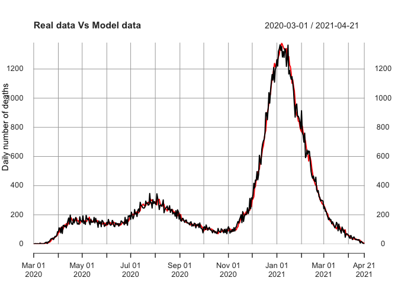

```r
fit.r <- covid$deaths  # real values - last 31 observations, last observation iis zero thats why i dint take it
fit.m <- xts(fitted(arima1),order.by=index(covid))# forecast
colors_ <- c("black", "red")
plot.xts(merge(fit.r, fit.m), plot.type="single",
         col = colors_,   # colors for subsequent lines
         ylab = "Daily number of deaths", # axes labels
         main = "Real data Vs Model data") # title above the plot
```

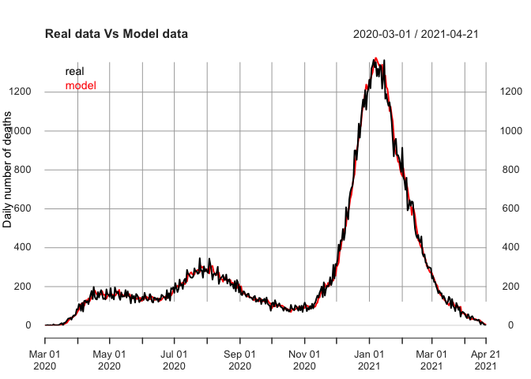

```r
addLegend("topleft", c("real","model"), text.col = colors_)
```

## Preparing the fprecast

### Time to start ppreparing for the forecastusing our model

lets see last 25% observations

```r
tail(covid, 104)
```

```
##            deaths
## 2021-01-08   1282
## 2021-01-09   1320
## 2021-01-10   1280
## 2021-01-11   1340
## 2021-01-12   1332
## 2021-01-13   1218
## 2021-01-14   1266
## 2021-01-15   1364
## 2021-01-16   1166
## 2021-01-17   1190
## 2021-01-18   1152
## 2021-01-19   1130
## 2021-01-20   1148
## 2021-01-21   1104
## 2021-01-22   1048
## 2021-01-23    958
## 2021-01-24    870
## 2021-01-25    950
## 2021-01-26    960
## 2021-01-27    876
## 2021-01-28    876
## 2021-01-29    860
## 2021-01-30    832
## 2021-01-31    790
## 2021-02-01    914
## 2021-02-02    764
## 2021-02-03    746
## 2021-02-04    698
## 2021-02-05    760
## 2021-02-06    592
## 2021-02-07    606
## 2021-02-08    644
## 2021-02-09    616
## 2021-02-10    638
## 2021-02-11    634
## 2021-02-12    562
## 2021-02-13    498
## 2021-02-14    466
## 2021-02-15    450
```

[output cut: 50 more lines]

```
## 2021-04-07     44
## 2021-04-08     48
## 2021-04-09     38
## 2021-04-10     30
## 2021-04-11     28
## 2021-04-12     30
## 2021-04-13     26
## 2021-04-14     30
## 2021-04-15     18
## 2021-04-16      6
## 2021-04-17     18
## 2021-04-18     12
## 2021-04-19      6
## 2021-04-20      2
## 2021-04-21      0
```

```r
covid.sample <- covid["/2021-01-07", 1]

tail(covid.sample)
```

```
##            deaths
## 2021-01-02   1220
## 2021-01-03   1322
## 2021-01-04   1338
## 2021-01-05   1366
## 2021-01-06   1328
## 2021-01-07   1354
```

## FORECAST for death

### model arima515

Estimating the model on shorter sample

```r
arima515s <- Arima(covid.sample$deaths,  # variable
                   order = c(5,1,5),   # (p,d,q) parameters
                   include.constant = T)

arima515s
```

```
## Series: covid.sample$deaths
## ARIMA(5,1,5) with drift
##
## Coefficients:
##          ar1      ar2      ar3     ar4      ar5      ma1     ma2     ma3
##       0.3757  -0.1172  -0.1245  0.8997  -0.0965  -1.0718  0.5098  0.0283
## s.e.  0.1282   0.1001   0.0958  0.0762   0.0859   0.1146  0.1845  0.2027
##           ma4     ma5   drift
##       -0.8740  0.6531  5.3486
## s.e.   0.1703  0.0803  4.9922
##
## sigma^2 estimated as 673.5:  log likelihood=-1456.7
## AIC=2937.41   AICc=2938.45   BIC=2982.32
```

## Prediction

### Forecasting using the model

```r
forecast515  =  forecast(arima515s, # model for prediction
                         h = 104) # how many periods outside the sample
```

## Results

```r
forecast515
```

```
##     Point Forecast    Lo 80    Hi 80    Lo 95    Hi 95
## 314       1391.768 1358.413 1425.123 1340.756 1442.780
## 315       1411.132 1376.262 1446.001 1357.804 1464.459
## 316       1402.892 1365.193 1440.591 1345.236 1460.548
## 317       1436.765 1395.988 1477.543 1374.402 1499.129
## 318       1459.262 1414.101 1504.423 1390.194 1528.330
## 319       1478.882 1430.350 1527.414 1404.659 1553.106
## 320       1470.452 1416.941 1523.963 1388.614 1552.290
## 321       1493.791 1434.842 1552.740 1403.636 1583.946
## 322       1518.412 1452.908 1583.915 1418.233 1618.591
## 323       1541.794 1470.828 1612.760 1433.261 1650.327
## 324       1535.644 1458.380 1612.909 1417.478 1653.810
## 325       1549.674 1465.673 1633.675 1421.206 1678.143
## 326       1572.990 1481.253 1664.727 1432.690 1713.290
## 327       1599.868 1501.264 1698.473 1449.066 1750.671
```

[output cut: 90 more lines]

The forecasts are indexed with a observation number,not a date!

```r
class(forecast515$mean)
```

```
## [1] "ts"
```

```r
# it is a ts object, not xts


# it includes:
# Point Forecast - predicted values
forecast515$mean
```

```
## Time Series:
## Start = 314
## End = 417
## Frequency = 1
##   [1] 1391.768 1411.132 1402.892 1436.765 1459.262 1478.882 1470.452 1493.791
##   [9] 1518.412 1541.794 1535.644 1549.674 1572.990 1599.868 1598.033 1604.842
##  [17] 1624.227 1653.209 1657.069 1659.347 1673.261 1702.282 1712.283 1712.919
##  [25] 1721.005 1747.827 1763.411 1765.058 1768.060 1790.742 1810.475 1815.171
##  [33] 1814.675 1831.934 1853.793 1862.701 1860.773 1872.194 1893.939 1907.252
##  [41] 1906.023 1912.091 1931.655 1948.662 1949.950 1951.917 1967.740 1987.043
##  [49] 1992.049 1991.678 2002.930 2022.755 2031.907 2031.140 2037.806 2056.346
##  [57] 2069.284 2069.904 2072.719 2088.466 2104.163 2107.509 2107.774 2119.759
##  [65] 2136.752 2143.532 2142.845 2150.770 2167.452 2177.672 2177.634 2181.876
##  [73] 2196.782 2209.811 2211.746 2213.246 2225.298 2240.029 2244.784 2244.842
##  [81] 2253.506 2268.589 2276.426 2276.452 2281.791 2295.888 2306.487 2307.755
##  [89] 2310.370 2322.388 2334.951 2338.390 2339.280 2348.543 2361.970 2368.036
##  [97] 2368.392 2374.727 2387.832 2396.467 2397.458 2401.187 2412.912 2423.597
```

```r
# 80% and 95% confidence intervals
forecast515$lower
```

```
## Time Series:
## Start = 314
## End = 417
## Frequency = 1
##          80%      95%
## 314 1358.413 1340.756
## 315 1376.262 1357.804
## 316 1365.193 1345.236
## 317 1395.988 1374.402
## 318 1414.101 1390.194
## 319 1430.350 1404.659
## 320 1416.941 1388.614
## 321 1434.842 1403.636
## 322 1452.908 1418.233
## 323 1470.828 1433.261
```

[output cut: 94 more lines]

```r
forecast515$upper
```

```
## Time Series:
## Start = 314
## End = 417
## Frequency = 1
##          80%      95%
## 314 1425.123 1442.780
## 315 1446.001 1464.459
## 316 1440.591 1460.548
## 317 1477.543 1499.129
## 318 1504.423 1528.330
## 319 1527.414 1553.106
## 320 1523.963 1552.290
## 321 1552.740 1583.946
## 322 1583.915 1618.591
## 323 1612.760 1650.327
```

[output cut: 94 more lines]

If we want to easily put together both real data and the forecast on the plot, we have to convert both to ts or both to xts objects

```r
class(covid)
```

```
## [1] "xts" "zoo"
```

```r
tail(covid, 104) # indexed by date
```

```
##            deaths
## 2021-01-08   1282
## 2021-01-09   1320
## 2021-01-10   1280
## 2021-01-11   1340
## 2021-01-12   1332
## 2021-01-13   1218
## 2021-01-14   1266
## 2021-01-15   1364
## 2021-01-16   1166
## 2021-01-17   1190
## 2021-01-18   1152
## 2021-01-19   1130
## 2021-01-20   1148
## 2021-01-21   1104
## 2021-01-22   1048
## 2021-01-23    958
## 2021-01-24    870
## 2021-01-25    950
## 2021-01-26    960
## 2021-01-27    876
## 2021-01-28    876
## 2021-01-29    860
## 2021-01-30    832
## 2021-01-31    790
## 2021-02-01    914
## 2021-02-02    764
## 2021-02-03    746
## 2021-02-04    698
## 2021-02-05    760
## 2021-02-06    592
## 2021-02-07    606
## 2021-02-08    644
## 2021-02-09    616
## 2021-02-10    638
## 2021-02-11    634
## 2021-02-12    562
## 2021-02-13    498
## 2021-02-14    466
## 2021-02-15    450
```

[output cut: 50 more lines]

```
## 2021-04-07     44
## 2021-04-08     48
## 2021-04-09     38
## 2021-04-10     30
## 2021-04-11     28
## 2021-04-12     30
## 2021-04-13     26
## 2021-04-14     30
## 2021-04-15     18
## 2021-04-16      6
## 2021-04-17     18
## 2021-04-18     12
## 2021-04-19      6
## 2021-04-20      2
## 2021-04-21      0
```

```r
# ts() function does easily convert xts to ts object

class(ts(covid))
```

```
## [1] "ts"
```

```r
tail(ts(covid), 104) # indexed by observation number
```

```
## Time Series:
## Start = 314
## End = 417
## Frequency = 1
##        deaths
##   [1,]   1282
##   [2,]   1320
##   [3,]   1280
##   [4,]   1340
##   [5,]   1332
##   [6,]   1218
##   [7,]   1266
##   [8,]   1364
##   [9,]   1166
##  [10,]   1190
```

[output cut: 169 more lines]

## Plot with the Forecast

### Long term forecast

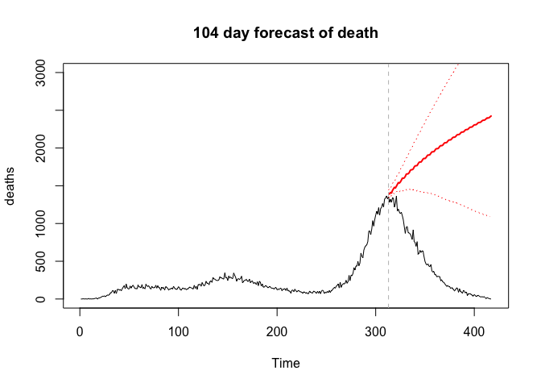

```r
# original data
plot(ts(covid[,1]), main = "104 day forecast of death",xlim = c(0,418), ylim = c(0, 3000))
# line at the end of a sample period (start of the forecast)
# observation number 388
abline(v = 313, lty = 2, col = "gray")
# line for the forecast
lines(forecast515$mean, col = "red", lwd = 2)
# line for the 95% confidence interval
# indexed by observation numbers from the forecast
lines(313:416,forecast515$lower[,2], col = "red", lty = 3)
lines(313:416,forecast515$upper[,2], col = "red", lty = 3)
```

As we can the out forecast is very poor and not suffiecent. However we can try forecasting with our model for shorter time period Now will try with shorter time period means also with fewer observaions

```r
tail(covid, 31)
```

```
##            deaths
## 2021-03-22     92
## 2021-03-23     74
## 2021-03-24    116
## 2021-03-25    102
## 2021-03-26     80
## 2021-03-27     94
## 2021-03-28     46
## 2021-03-29     68
## 2021-03-30     70
## 2021-03-31     66
## 2021-04-01     60
## 2021-04-02     46
## 2021-04-03     38
## 2021-04-04     60
## 2021-04-05     46
## 2021-04-06     30
## 2021-04-07     44
## 2021-04-08     48
## 2021-04-09     38
## 2021-04-10     30
## 2021-04-11     28
## 2021-04-12     30
## 2021-04-13     26
## 2021-04-14     30
## 2021-04-15     18
## 2021-04-16      6
## 2021-04-17     18
## 2021-04-18     12
## 2021-04-19      6
## 2021-04-20      2
## 2021-04-21      0
```

```r
# we cut last 31 observations (since 2021-03-22 )
# and keep them aside as the out-of-sample
# to perform a forecasting exercise
# and have a possibility to assess it

covid.sample <- covid["/2021-03-22", 1]

tail(covid.sample)
```

```
##            deaths
## 2021-03-17    148
## 2021-03-18    138
## 2021-03-19     90
## 2021-03-20    136
## 2021-03-21    100
## 2021-03-22     92
```

## FORECAST for death

### Estimating the model on shorter sample

```r
arima515s <- Arima(covid.sample$deaths,  # variable
                   order = c(5,1,5),   # (p,d,q) parameters
                   include.constant = T)

arima515s
```

```
## Series: covid.sample$deaths
## ARIMA(5,1,5) with drift
##
## Coefficients:
##          ar1     ar2      ar3      ar4      ar5      ma1      ma2     ma3
##       0.5638  1.0274  -0.2013  -0.2387  -0.1708  -1.1670  -0.6981  0.9371
## s.e.  0.2079  0.2702   0.2611   0.2309   0.1011   0.2078   0.3663  0.2872
##          ma4      ma5   drift
##       0.1994  -0.2296  0.2681
## s.e.  0.3258   0.1733  3.2929
##
## sigma^2 estimated as 989.6:  log likelihood=-1874.72
## AIC=3773.44   AICc=3774.28   BIC=3820.91
```

## Prediction short term

```r
forecast515  =  forecast(arima515s, # model for prediction
                         h = 31) # how many periods outside the sample
```

## Result short term

```r
forecast515
```

```
##     Point Forecast       Lo 80    Hi 80       Lo 95    Hi 95
## 388      103.11516   62.799750 143.4306   41.458063 164.7723
## 389      107.85236   64.479113 151.2256   41.518701 174.1860
## 390       97.45077   51.370555 143.5310   26.977164 167.9244
## 391      104.19229   53.960204 154.4244   27.368942 181.0156
## 392       99.22825   42.957504 155.4990   13.169569 185.2869
## 393      102.42532   41.751611 163.0990    9.632892 195.2177
## 394       99.44979   31.736943 167.1626   -4.108072 203.0076
## 395      102.22888   28.404200 176.0536  -10.676226 215.1340
## 396      100.13377   18.382454 181.8851  -24.894081 225.1616
## 397      102.49680   13.209305 191.7843  -34.056639 239.0502
## 398      101.28657    3.021495 199.5516  -48.996893 251.5700
## 399      103.30388   -3.750771 210.3585  -60.422080 267.0298
## 400      102.75283  -14.229320 219.7350  -76.155930 281.6616
## 401      104.55740  -22.307696 231.4225  -89.466020 298.5808
```

[output cut: 17 more lines]

The forecasts are indexed with a observation number, not a date!

```r
class(forecast515$mean)
```

```
## [1] "ts"
```

```r
# it is a ts object, not xts


# it includes:
# Point Forecast - predicted values
forecast515$mean
```

```
## Time Series:
## Start = 388
## End = 418
## Frequency = 1
##  [1] 103.11516 107.85236  97.45077 104.19229  99.22825 102.42532  99.44979
##  [8] 102.22888 100.13377 102.49680 101.28657 103.30388 102.75283 104.55740
## [15] 104.49307 106.15215 106.45038 108.00461 108.56564 110.03891 110.78372
## [22] 112.18761 113.05358 114.39195 115.32940 116.60153 117.57118 118.77397
## [29] 119.74507 120.87455 121.82340
```

```r
# 80% and 95% confidence intervals
forecast515$lower
```

```
## Time Series:
## Start = 388
## End = 418
## Frequency = 1
##             80%         95%
## 388   62.799750   41.458063
## 389   64.479113   41.518701
## 390   51.370555   26.977164
## 391   53.960204   27.368942
## 392   42.957504   13.169569
## 393   41.751611    9.632892
## 394   31.736943   -4.108072
## 395   28.404200  -10.676226
## 396   18.382454  -24.894081
## 397   13.209305  -34.056639
```

[output cut: 21 more lines]

```r
forecast515$upper
```

```
## Time Series:
## Start = 388
## End = 418
## Frequency = 1
##          80%      95%
## 388 143.4306 164.7723
## 389 151.2256 174.1860
## 390 143.5310 167.9244
## 391 154.4244 181.0156
## 392 155.4990 185.2869
## 393 163.0990 195.2177
## 394 167.1626 203.0076
## 395 176.0536 215.1340
## 396 181.8851 225.1616
## 397 191.7843 239.0502
```

[output cut: 21 more lines]

If we want to easily put together both real data and the forecast on the plot, we have to convert both to ts or both to xts objects

```r
class(covid)
```

```
## [1] "xts" "zoo"
```

```r
tail(covid, 31) # indexed by date
```

```
##            deaths
## 2021-03-22     92
## 2021-03-23     74
## 2021-03-24    116
## 2021-03-25    102
## 2021-03-26     80
## 2021-03-27     94
## 2021-03-28     46
## 2021-03-29     68
## 2021-03-30     70
## 2021-03-31     66
## 2021-04-01     60
## 2021-04-02     46
## 2021-04-03     38
## 2021-04-04     60
## 2021-04-05     46
## 2021-04-06     30
## 2021-04-07     44
## 2021-04-08     48
## 2021-04-09     38
## 2021-04-10     30
## 2021-04-11     28
## 2021-04-12     30
## 2021-04-13     26
## 2021-04-14     30
## 2021-04-15     18
## 2021-04-16      6
## 2021-04-17     18
## 2021-04-18     12
## 2021-04-19      6
## 2021-04-20      2
## 2021-04-21      0
```

ts() function does easily convert xts to ts object

```r
class(ts(covid))
```

```
## [1] "ts"
```

```r
tail(ts(covid), 31)
```

```
## Time Series:
## Start = 387
## End = 417
## Frequency = 1
##       deaths
##  [1,]     92
##  [2,]     74
##  [3,]    116
##  [4,]    102
##  [5,]     80
##  [6,]     94
##  [7,]     46
##  [8,]     68
##  [9,]     70
## [10,]     66
```

[output cut: 96 more lines]

## Plot with the Forecast

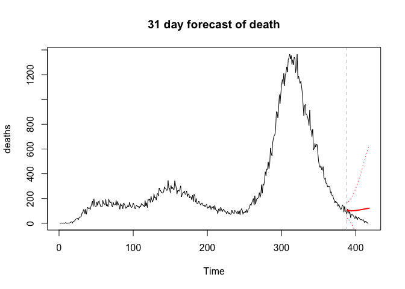

```r
plot(ts(covid$deaths), main = "31 day forecast of death")
# line at the end of a sample period (start of the forecast)
# observation number 388
abline(v = 388, lty = 2, col = "gray")
# line for the forecast
lines(forecast515$mean, col = "red", lwd = 2)
# line for the 95% confidence interval
# indexed by observation numbers from the forecast
lines(388:418,forecast515$lower[,2], col = "red", lty = 3)
lines(388:418,forecast515$upper[,2], col = "red", lty = 3)
```

### Zoomed plot

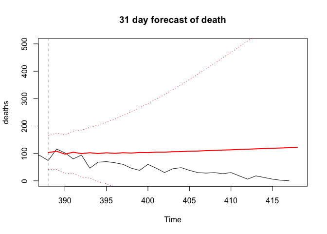

```r
plot(ts(covid[,1]), main = "31 day forecast of death",
     xlim = c(388,418), ylim = c(0, 500))
abline(v = 388, lty = 2, col = "gray")
lines(forecast515$mean, col = "red", lwd = 2)
lines(388:418,forecast515$lower[,2], col = "red", lty = 3)
lines(388:418,forecast515$upper[,2], col = "red", lty = 3)
```

## Quality Check

Checking forecast quality:for simplicity of the following formulas lets define two new objects:

```r
death.r <- tail(covid$death[-417], 31)  # real values - last 31 observations, last observation iis zero thats why i dint take it
death.f <- as.numeric(forecast515$mean) # forecast

death_forecast <- data.frame(death.r, death.f)
```

### Basis of different measures

lets add the basis for different measures of the forecast error

```r
death_forecast$mae  =  abs(death.r - death.f)
death_forecast$mse  =  (death.r - death.f)^2
death_forecast$mape  =  abs((death.r - death.f)/death.r)
death_forecast$amape  =  abs((death.r - death.f)/(death.r+death.f))
```

### Average Error

```r
colMeans(death_forecast[,3:6])
```

```
##          mae          mse         mape        amape
##   60.0152808 4806.5596873    4.8070306    0.4222189
```

## Conclusion

Our forecast on short time period seems to be more accurate. However as our forecast is not as accurate we as supposed, we cannot verify our main hypothesis that death cases will decline significantly NOTE: Despite performing better in the sample, does not mean the Model will necessarily be the best for forecasting

## Bibliography

Although, we used different literature as a source to compare our work and to check our step by step approach, everything is done according to our lectures and labs. To avoid complication and further misunderstanding we didnt tend to use other ways or methodologies rather than what we have been taught in the classes. However, to check and compare our results many sources have been used, which I mentioned in the literature review!